# R Notebook: Homework 1

Orli Khaimova

**Principles of Data Visualization and Introduction to ggplot2**

I have provided you with data about the 5,000 fastest growing companies in the US, as compiled by Inc. magazine. lets read this in:

And lets preview this data:

|  | Rank | Name | Growth_Rate | Revenue | Industry | Employees | City | State |
| --- | --- | --- | --- | --- | --- | --- | --- | --- |
| 1 | 1 | Fuhu | 421.48 | 1.179e+08 | Consumer Products & Services | 104 | El Segundo | CA |
| 2 | 2 | FederalConference.com | 248.31 | 4.960e+07 | Government Services | 51 | Dumfries | VA |
| 3 | 3 | The HCI Group | 245.45 | 2.550e+07 | Health | 132 | Jacksonville | FL |
| 4 | 4 | Bridger | 233.08 | 1.900e+09 | Energy | 50 | Addison | TX |
| 5 | 5 | DataXu | 213.37 | 8.700e+07 | Advertising & Marketing | 220 | Boston | MA |
| 6 | 6 | MileStone Community Builders | 179.38 | 4.570e+07 | Real Estate | 63 | Austin | TX |

```r
summary(inc)
```

```
      Rank          Name            Growth_Rate         Revenue            Industry           Employees
 Min.   :   1   Length:5001        Min.   :  0.340   Min.   :2.000e+06   Length:5001        Min.   :    1.0
 1st Qu.:1252   Class :character   1st Qu.:  0.770   1st Qu.:5.100e+06   Class :character   1st Qu.:   25.0
 Median :2502   Mode  :character   Median :  1.420   Median :1.090e+07   Mode  :character   Median :   53.0
 Mean   :2502                      Mean   :  4.612   Mean   :4.822e+07                      Mean   :  232.7
 3rd Qu.:3751                      3rd Qu.:  3.290   3rd Qu.:2.860e+07                      3rd Qu.:  132.0
 Max.   :5000                      Max.   :421.480   Max.   :1.010e+10                      Max.   :66803.0
                                                                                            NA's   :12
     City              State
 Length:5001        Length:5001
 Class :character   Class :character
 Mode  :character   Mode  :character
```

Think a bit on what these summaries mean. Use the space below to add some more relevant non-visual exploratory information you think helps you understand this data:

```r
str(inc)
```

```
'data.frame':   5001 obs. of  8 variables:
 $ Rank       : int  1 2 3 4 5 6 7 8 9 10 ...
 $ Name       : chr  "Fuhu" "FederalConference.com" "The HCI Group" "Bridger" ...
 $ Growth_Rate: num  421 248 245 233 213 ...
 $ Revenue    : num  1.18e+08 4.96e+07 2.55e+07 1.90e+09 8.70e+07 ...
 $ Industry   : chr  "Consumer Products & Services" "Government Services" "Health" "Energy" ...
 $ Employees  : int  104 51 132 50 220 63 27 75 97 15 ...
 $ City       : chr  "El Segundo" "Dumfries" "Jacksonville" "Addison" ...
 $ State      : chr  "CA" "VA" "FL" "TX" ...
```

```r
Industry
```

```
Error: object 'Industry' not found
```

## Question 1

Create a graph that shows the distribution of companies in the dataset by State (ie how many are in each state). There are a lot of States, so consider which axis you should use. This visualization is ultimately going to be consumed on a ‘portrait’ oriented screen (ie taller than wide), which should further guide your layout choices.

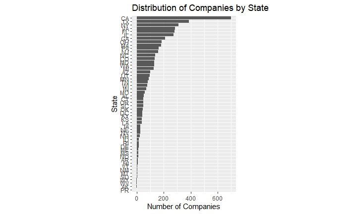

## Quesiton 2

Lets dig in on the state with the 3rd most companies in the data set. Imagine you work for the state and are interested in how many people are employed by companies in different industries. Create a plot that shows the average and/or median employment by industry for companies in this state (only use cases with full data, use R’s `complete.cases()` function.) In addition to this, your graph should show how variable the ranges are, and you should deal with outliers.

Box plots help in visualizing the medians and the variability of each range. At first glance, there was a major outlier for “Business Products & Services” with 32,000 employees and another one for “Consumer Products & Services” with 10,000 employees. I filtered out companies with over 2,000 employees.

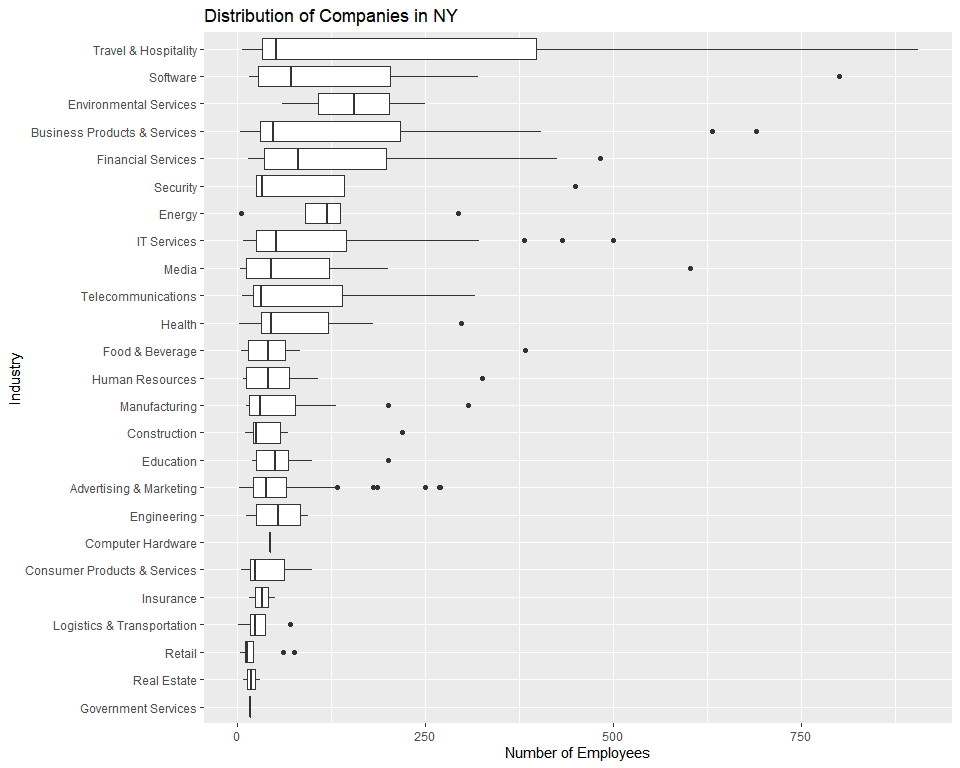

## Question 3

Now imagine you work for an investor and want to see which industries generate the most revenue per employee. Create a chart that makes this information clear. Once again, the distribution per industry should be shown.

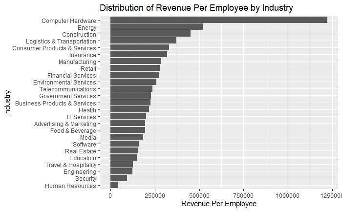

```r
inc %>%
  filter(complete.cases(.)) %>%
  group_by(Industry) %>%
  summarise(Employees_n = sum(Employees),
            Revenue_n = sum(Revenue)) %>%
  mutate(Revenue_Per_Employee = Revenue_n / Employees_n) %>%
  ggplot(., aes(x= Revenue_Per_Employee, y = reorder(Industry, Revenue_Per_Employee))) +
  geom_bar(stat = "identity", ) +
  labs(title = "Distribution of Revenue Per Employee by Industry", y = "Industry",
       x = "Revenue Per Employee")
```